# Pró direitos humanos : Direita (X) Esquerda

```r
respostas = read_csv(here::here("data/respostas-merepresenta-2016.csv"),
                     col_types = cols(.default = col_character(),
                                      nota_partido = col_integer(),
                                      votos_recebidos = col_integer()))
# A versão long (em vez de wide) dos dados facilita muito pro ggplot:
respostas_long =
    respostas %>%
    gather(key = "tema",
           value = "resposta",
           10:23) %>%
  mutate(lado = sigla_partido %in% c("PT","PDT","PTdoB","PSB","PROS","REDE","PSOL","PC do B","PCB"))
```

Para conhcer mais os dados iremos observar quais os temas presente e sua proporção do temas mais aprovados e menos aprovados.

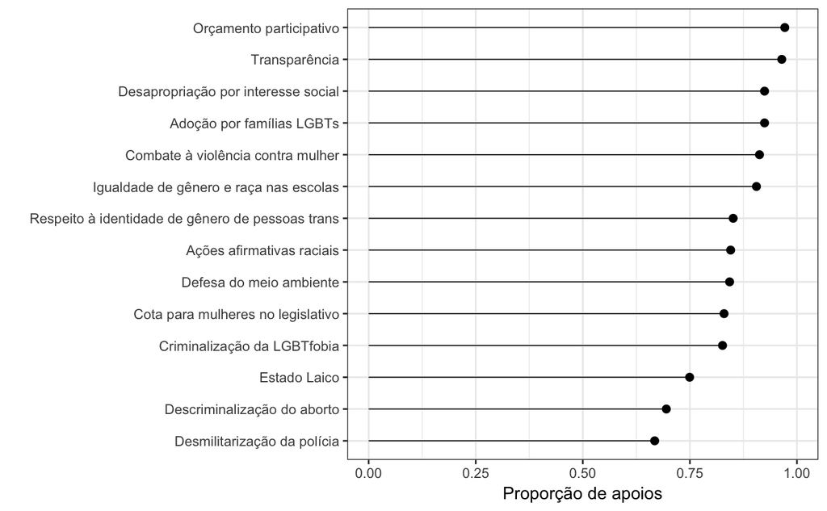

Como podemos observar os temas que foram votado e sua proporção considerando que o tema orçamento participativo como o tema de mais interesse de todos os que votaram e desmilitarização da policia como o o menos vota entre os candidados.

## Qual partido está mais em defesa dos temas relacionados a classe LGBT?

Para verificar está associação analisamos a proporção associada ao numero de respostas á favor desses temas e os partidos que são á favor desses temas.

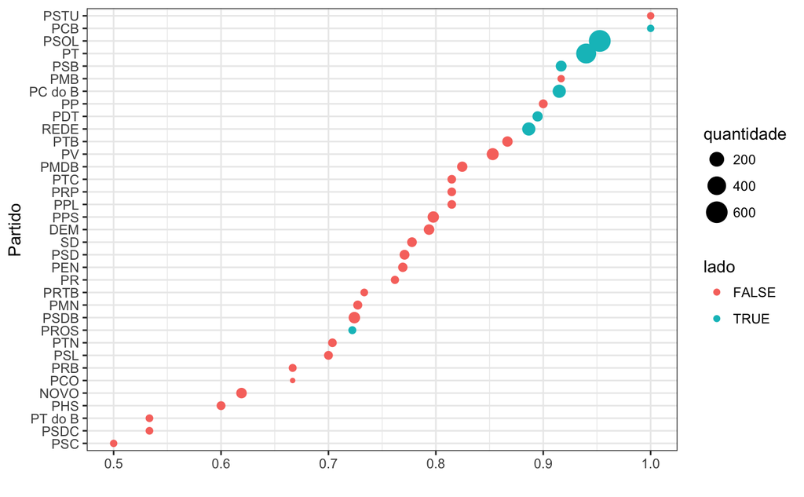

## Qual Estádo onde onde o tema sobre violência contra mulher é mais considerado entre os candidatos.

Utilizaremos medida de proporção em relação aos estados com o tema de Combate à violência conta mulher e assim também observar se direita ou esquerda qual lado estária mais á favor deste tema.

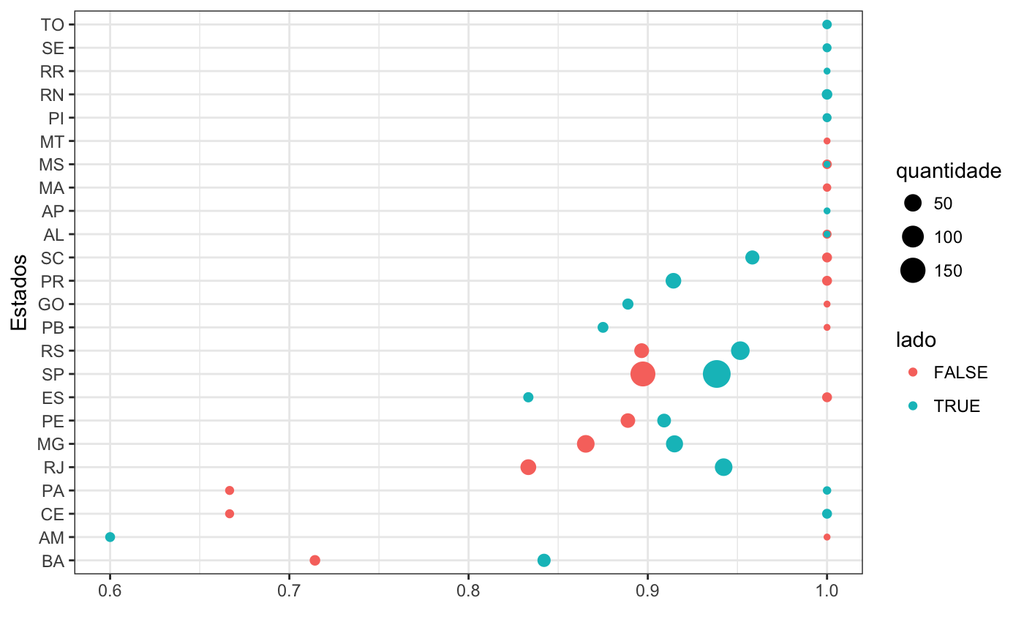

Como podemos observar em sua maioria os em relação aos estados são á favor do combate da violência contra a mulher observamos a proporção 1, mas podemos considerar que o número de candidatos desses estados como algo pequeno diante da amostra. Podemos considerar o estado de São Paulo em específico em que os lados de Esquerda (x) Direita toda proporções um pouco diferente e nesse estado observamos um número considerável de candidatos que respondeu o questionário assim observamos que a proporção dos candidatos de Esquerda um pouco maior, mas considerando ambos os lados o estado tem uma proporção boa de candidatos á favor do tema.

### Qual gênero é mais favoravel com a causa LGBT?

Para isso analisamos como está a distribuição de homens e mulheres nos dados

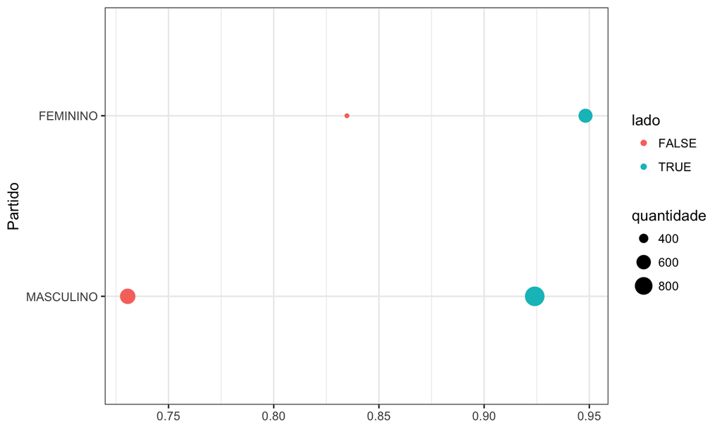

Observamos que a proporção de mulheres que apoia causas com temas relacionados a classe LGBT maiores do que a dos homens e podemos observa também que em sua (maioria) tanto homens e mulheres da Esquerda tem uma proporção maior de serem á favores dessas temáticas. Observamos que homens de partidos do lado direito tende á ser mais contra a esses temas.